# Learnalike Online learning Questionnaire Analysis

Let's take a look at the data set first to understand what kinds of data is available

First importing some libraries that will be used through the analysis.

```python
import numpy as np
import pandas as pd
import seaborn as sn
```

### The purpose of this questionnaire was to get information from our initial target groups. Namely : Coworking space members and Students about their online learning habits. The reason we took Coworking space groups is because they are quite representative of the three groups, freelances, regular employees, interns / students. So is a good place to start.

This questionnaire was designed to understand the patterns of how people learn online. It was completely anonymous and took on an average about 5 minutes to complete.

For 48% of people the source of learning does not matter. Just finding the article matters. Giving people reasons to start learning

People have a strong need for social interaction but they don’t do it while learning because its hard. Making it easy is key. How is part - 2.

Huge percent of people learn 73.3% on youtube. Its free and it has all the content! But these same people have problems.

You don’t know what you don’t know and this needs to be bridged.

Everyone wants to learn languages!!! But not everyone knows who all in their in circles

People don’t know what they’re missing when it comes to social learning online because they have not experienced it.

Open questions :

1. Cross disciplinary isolation. How do you solve this? People do not know where each other stood in terms of what they know?
2. Who studies online more with moocs co-working people or students?
3. Is gender reflective of learning online / Is gender reflective of tech / non- technical roles / interests.
4. Which age group is learning more with MOOCs 18-23 / 24-30?
5. Is level of education correlated with online learnin for coworking spaces.
6. Among the free / self employed Vs employed for wages how many are actually learning online
7. Which are the top fields for online learning for coworking spaces?
8. How many people in a given field want are interested in other fields.
9. Which areas of interest are people learning most online in coworking spaces?
10. What motivates people in coworking spaces to learn online?
11. If people are personally motivated why do they not learn?
12. Is there a difference between how often coworking group that does not meet each other often but values it quite a lot.
13. What % of people the not-meeting often type are actually wanting to have high levels of social interaction.
14. Could most people not pay for online courses because they think it is not as beneficial as university where you have social interaction?
15. Are coworking space people paying? Who is paying?

```python
ol = pd.read_csv("learn_questions.csv")
```

```python
ol.head()
```

|  | Timestamp | Username | What is your gender? | What is your age? | What is the highest level of education you have completed? | What is your current employment status? | What field best describes your current occupation? | Where do you live in the moment? | Do you currently work in a coworking space? | If yes in which? | ... | How many online courses have you completed already? | Have you ever paid for a course online? | What are you biggest problems learning online? (Choose at max 3) | Which factors are most important to you while taking up a new course? (Choose at max 3) | How long does it take you to find the right course online? | How often do you learn online? | Do you want to sign up for our restricted beta? | If yes, please provide your email. | Who asked you to do this questionnaire? | Unnamed: 27 |
| --- | --- | --- | --- | --- | --- | --- | --- | --- | --- | --- | --- | --- | --- | --- | --- | --- | --- | --- | --- | --- | --- |
| 0 | 2017/11/30 11:28:21 am CET | fa.fuerst@gmail.com | Male | 18 - 23 | High School Diploma | Self-employed (Founder, Freelancer,...) | Entrepreneurship | Europe | Yes | NaN | ... | 5 - 9 | Yes | No social interaction, difficult to find the r... | Course Content & Structure;Costs;Course Durati... | NaN | Everyday | Yes | NaN | NaN | 2.0 |
| 1 | 2017/11/30 3:36:07 pm CET | christoph.bernkopf95@gmail.com | Male | 18 - 23 | Bachelor's Degree or comparable | Self-employed (Founder, Freelancer,...) | Entrepreneurship | Europe | Yes | NaN | ... | 10 and more | Yes | Finding advanced courses, getting help when st... | Course Content & Structure;Course Duration & F... | NaN | Everyday | Yes | NaN | NaN | 3.0 |
| 2 | 2017/11/30 9:13:48 pm CET | f.montemayor26@gmail.com | Male | 18 - 23 | Bachelor's Degree or comparable | Student | Software Development | Latin America | No | NaN | ... | NaN | NaN | NaN | NaN | NaN | NaN | No | NaN | Fabian Fürst | NaN |
| 3 | 2017/11/30 9:19:13 pm CET | maria.hercole@hotmail.com | Female | 18 - 23 | Bachelor's Degree or comparable | Student | Marketing & PR | Latin America | Yes | NaN | ... | 1 - 2 | No | Very autodidact, you have to be very responsible. | Instructor Expertise;Friend's Recommendation;C... | NaN | Once a week | Yes | NaN | Fabian Fürst | 6.0 |
| 4 | 2017/11/30 9:19:38 pm CET | alexander.j.goetz@gmail.com | Male | 18 - 23 | High School Diploma | Student | Science | Europe | No | NaN | ... | 1 - 2 | No | I spend hours searching for the information | Friend's Recommendation;Course Reviews;Course ... | NaN | Everyday | Yes | NaN | Fabian Fürst | 2.0 |

5 rows × 28 columns

Dropping some dataframe columns that are not that interesting to analyse

```python
ol.drop(['Timestamp'], axis=1) #dropping timestamp
```

[output not shown]

207 rows × 27 columns

Converting the following into Binaries or categories to make analysis simpler

1. Sex - Male and Female in 1.0 and - 1.0
2. Do you currently work in a coworking space?

   ```
    a. Yes - 1
    b. No - 0
   ```

3. Have you ever learned online, eg. with Youtube, Coursera, Udacity, edX, Udemy ?

   ```
    a. Yes - 1
    b. No - 0
   ```

4. Have you ever paid for a course online?

   ```
    a. Yes - 1
    b. No - 0
   ```

5. Do you want to sign up for our restricted beta?

   ```
    a. Yes - 1
    b. No - 0
   ```

```python
olBin = ol.replace(to_replace =['Male', 'Female','Yes', 'No' ],value =[1,0, 1,0])
```

### Getting the headers in all the questionnaire

```python
olBin.dtypes
```

```
Timestamp                                                                                   object
Username                                                                                    object
What is your gender?                                                                        object
What is your age?                                                                           object
What is the highest level of education you have completed?                                  object
What is your current employment status?                                                     object
What field best describes your current occupation?                                          object
Where do you live in the moment?                                                            object
Do you currently work in a coworking space?                                                  int64
If yes in which?                                                                            object
Which best specifies your areas of interest? (Choose at max 3)                              object
What describes best your motivation to learn? (Choose at max 3)                             object
What time of the day are you most likely to learn something new?                            object
How often do you interact with someone who is learning the same topics as you are?          object
How important is social interaction while learning for you?                                  int64
How do you learn? (Select at max 3)                                                         object
Have you ever learned online, eg. with Youtube, Coursera, Udacity, edX, Udemy ?              int64
Have you used any of the following platforms? Please select all that apply.                 object
How many online courses have you completed already?                                         object
Have you ever paid for a course online?                                                    float64
What are you biggest problems learning online? (Choose at max 3)                            object
Which factors are most important to you while taking up a new course? (Choose at max 3)     object
How long does it take you to find the right course online?                                 float64
How often do you learn online?                                                              object
Do you want to sign up for our restricted beta?                                              int64
If yes, please provide your email.                                                          object
Who asked you to do this questionnaire?                                                     object
Unnamed: 27                                                                                float64
dtype: object
```

### Counting number of people in coworking spaces that also learn something online.

```python
coworkers = sum(np.where(olBin['Do you currently work in a coworking space?'] == 1)) # coworkers from data set
print len(coworkers)
```

```
70
```

```python
70/207.0
```

```
0.33816425120772947
```

## 70 Response are from Coworkers in this dataset that's 33.81% of total responses.

```python
onliners = sum(np.where(olBin['Have you ever learned online, eg. with Youtube, Coursera, Udacity, edX, Udemy ? '] == 1)) #online learners from data set
print  len(onliners) / 207.0
```

```
0.826086956522
```

## 82.6% of all responders have learnt online

```python
payers = sum(np.where(olBin['Have you ever paid for a course online?'] == 1.0))
len(payers) / 207.0
```

```
0.2608695652173913
```

## 26% of all responders have paid for a course online

```python
float(len(np.intersect1d(coworkers, onliners))) / 70 * 100
```

```
85.71428571428571
```

## 85.7% of Coworking space members have learnt a course online, i.e 60 out of 70

```python
from functools import reduce
cowork_online_payers = reduce(np.intersect1d,(coworkers,onliners, payers))
print len(cowork_online_payers)
```

```
21
```

```python
(21.0/70)* 100
```

```
30.0
```

## 30% of Coworking online learners also paid for a course. Slightly above average.

## Motivation to learn had a total of 609 responses in total, out of 207 people.

```python
sum(olBin['What describes best your motivation to learn? (Choose at max 3)'].str.count("Personal Development")) \
+ sum (olBin['What describes best your motivation to learn? (Choose at max 3)'].str.count("Career Development")) \
+ sum((olBin['What describes best your motivation to learn? (Choose at max 3)'].str.count("Personal Curiosity")))
```

```
428
```

```python
(428.0 / 609) *100
```

```
70.27914614121511
```

```python
interactors1 = sum(np.where(olBin['How often do you interact with someone who is learning the same topics as you are?'] == "Everyday"))
interactors2 = sum(np.where(olBin['How often do you interact with someone who is learning the same topics as you are?'] == "Two or three times a week"))
socialites = np.union1d(interactors1, interactors2)
print "everyday:", len(interactors1)," two three times a week:", len(interactors2), "total :" , len(interactors1) + len(interactors2)
print "very social learners " , len(socialites)
```

```
everyday: 66  two three times a week: 70 total : 136
very social learners  136
```

```python
(136.0 / 207) * 100
```

```
65.70048309178745
```

## 65% of all learners turned out to highly social learners interacting with someone who is learning the same thing as they are daily or 2/3 times weekly

```python
len(np.intersect1d(socialites, coworkers))
```

```
46
```

```python
(46/ 136.0 ) *100
```

```
33.82352941176471
```

```python
socialImp7 = sum(np.where(olBin['How important is social interaction while learning for you?'] == 7))
socialImp6 =sum(np.where(olBin['How important is social interaction while learning for you?'] == 6))
socialImp5 = sum(np.where(olBin['How important is social interaction while learning for you?'] == 5))
socialImp = reduce(np.union1d, (socialImp7, socialImp6, socialImp5))
print len(socialImp7) + len(socialImp6) + len(socialImp5), "Social Interaction importance"
print len(socialImp)
```

```
136 Social Interaction importance
136
```

```python
(136.0 / 207 ) * 100
```

```
65.70048309178745
```

## 65% of all learners thought social interaction is quite important for them on a scale of 1- 7 while learning

```python
float(len(np.intersect1d(socialImp, coworkers))) / 70 * 100
```

```
80.0
```

### Next lets look at the problems faced by people learning online, the total responses here were 296 (one could mark at max 3 values).

### 172 people in total responded to this question.

```python
probMotivation = sum(np.where(olBin['What are you biggest problems learning online? (Choose at max 3)'].str.count('Motivation') ))
probInteraction = sum(np.where(olBin['What are you biggest problems learning online? (Choose at max 3)'].str.count('Iteractivity')))
probLackoftime = sum(np.where(olBin['What are you biggest problems learning online? (Choose at max 3)'].str.count('Lack of time')))
probNocommunity = sum(np.where(olBin['What are you biggest problems learning online? (Choose at max 3)'].str.count('No community')))
probSoc = sum(np.where(olBin['What are you biggest problems learning online? (Choose at max 3)'].str.count('Social')))
probFeedback = sum(np.where(olBin['What are you biggest problems learning online? (Choose at max 3)'].str.count('One-on-One Feedback')))
print len(probMotivation), len(probInteraction), len(probLackoftime), len(probNocommunity), len(probSoc), len(probFeedback)
## now lets form the union of problems which are social related for eg Social, feedback, No Community

probSocial = reduce(np.union1d, ( probNocommunity, probSoc, probFeedback))
# print probNocommunity, "\n", probSoc, "\n",  probFeedback, "\n", probSocial
probSocialAndMotivation = reduce (np.union1d, ( probNocommunity, probSoc, probFeedback, probMotivation))
print "people who responded social problems:", len(probSocial), ", people who responded both social and motivation problesm:", len(probSocialandmotivation)
```

```
92 71 88 63 60 70
people who responded social problems: 104 , people who responded both social and motivation problesm: 131
```

```python
(104.0/172) * 100 , (131.0/172) * 100
```

```
(60.46511627906976, 76.16279069767442)
```

## 60.5% of all thought no-social aspects while learning online was a big problem, 76.1% of all thought that social and motivation were primary problems

```python
float(len(np.intersect1d(probSocialAndMotivation, coworkers))) / 70 * 100
```

```
71.42857142857143
```

## 71.4% of all coworkers thought no-social and motivation were a huge problem for online learning

```python
learnBetaYes = sum(np.where(olBin['Do you want to sign up for our restricted beta?'] == 1.0))
print "People who said Yes to learntastic platform Beta after reading a short value prop :", len(learnBetayes)
```

[output not shown]

```python
print float(len(reduce(np.intersect1d,( coworkers, learnBetaYes, probSocialAndMotivation )))) / float(len(reduce(np.intersect1d,( coworkers, probSocialAndMotivation ))))* 100
print float(len(reduce(np.intersect1d,( coworkers, learnBetaYes )))) / 70 * 100
```

```
64.0
67.1428571429
```

## 64.0% of coworkers, who thought no social functions and motivations were a problem for their online learning said they would sign up for the learntastic platform.

## 67.1% of coworkers said they would sign up in general.

### Next lets take a look at factors most important while taking a course from 173 people, the total responses here were : 534 (as they could mark at max 3) - some even marked more than 3 at times

```python
factorFriendrecomm = sum(np.where(olBin['Which factors are most important to you while taking up a new course? (Choose at max 3)'].str.count("Friend's Recommendation") ))
factorForum = sum(np.where(olBin['Which factors are most important to you while taking up a new course? (Choose at max 3)'].str.count("Forum Activity") ))
factorOneonone = sum(np.where(olBin['Which factors are most important to you while taking up a new course? (Choose at max 3)'].str.count("One-on-One Sessions") ))
factorReview = sum(np.where(olBin['Which factors are most important to you while taking up a new course? (Choose at max 3)'].str.count("Course Reviews") ))
factorDepth = sum(np.where(olBin['Which factors are most important to you while taking up a new course? (Choose at max 3)'].str.count("Course Depth") ))
factorContent = sum(np.where(olBin['Which factors are most important to you while taking up a new course? (Choose at max 3)'].str.count("Course Content & Structure") ))
factorDuration =  sum(np.where(olBin['Which factors are most important to you while taking up a new course? (Choose at max 3)'].str.count("Course Duration & Flexibilty") ))
#print factorFriendrecomm,"\n", factorForum,"\n", factorOneonone,"\n", factorReview
factorSocial = reduce(np.union1d, ( factorFriendrecomm, factorForum, factorOneonone, factorReview))
#print factorSocial
factorContentDepth = reduce(np.union1d, ( factorDepth, factorContent))
#print factorFriendrecomm, "\n", factorForum,"\n", factorOneonone,"\n", factorReview
#print factorContentdepthstructduration

print "people who though social factors were relevant when choosing a course:", len(factorSocial), "\n"

print "people who though social factors were relevant when choosing a course:", len(factorContentDepth), "\n"

print "coworkers who thought social factors were relevant when choosing a course:", len(np.intersect1d(factorSocial, coworkers)), "\n"

print "coworkers who thought content structure and depth were relevant when choosing a course:", len(np.intersect1d(factorContentDepth, coworkers))
```

```
people who though social factors were relevant when choosing a course: 133

people who though social factors were relevant when choosing a course: 154

coworkers who thought social factors were relevant when choosing a course: 40

coworkers who thought content structure and depth were relevant when choosing a course: 49
```

```python
print (133.0 / 173)*100 , (154.0 / 173) * 100, (40.0 / 70)*100,  (49.0 / 70)*100
```

```
76.8786127168 89.0173410405 57.1428571429 70.0
```

```python
print "coworkers who thought social was a factor and would sign up:", len(reduce(np.intersect1d,(coworkers, factorSocial, learnBetaYes)))
```

[output not shown]

```python
23.0/ len(reduce(np.intersect1d,(coworkers, factorSocial))) * 100
```

```
57.49999999999999
```

## 57.5% of coworkers with social as factor said they were more likely to sign up for a Beta.

### Time for some correlations & heat maps.

Lets find correlations positive or negative between the binary variables in the different columns in the data set.

```python
olBin.corr(method='pearson', min_periods=1)
```

|  | Do you currently work in a coworking space? | How important is social interaction while learning for you? | Have you ever learned online, eg. with Youtube, Coursera, Udacity, edX, Udemy ? | Have you ever paid for a course online? | How long does it take you to find the right course online? | Do you want to sign up for our restricted beta? | Unnamed: 27 |
| --- | --- | --- | --- | --- | --- | --- | --- |
| Do you currently work in a coworking space? | 1.000000 | 0.205716 | 0.058567 | 0.054110 | -0.194255 | 0.214201 | -0.001045 |
| How important is social interaction while learning for you? | 0.205716 | 1.000000 | 0.068049 | 0.090420 | 0.101324 | 0.250083 | 0.118205 |
| Have you ever learned online, eg. with Youtube, Coursera, Udacity, edX, Udemy ? | 0.058567 | 0.068049 | 1.000000 | NaN | NaN | 0.275116 | NaN |
| Have you ever paid for a course online? | 0.054110 | 0.090420 | NaN | 1.000000 | -0.138872 | 0.061813 | 0.139926 |
| How long does it take you to find the right course online? | -0.194255 | 0.101324 | NaN | -0.138872 | 1.000000 | -0.161232 | NaN |
| Do you want to sign up for our restricted beta? | 0.214201 | 0.250083 | 0.275116 | 0.061813 | -0.161232 | 1.000000 | 0.111259 |
| Unnamed: 27 | -0.001045 | 0.118205 | NaN | 0.139926 | NaN | 0.111259 | 1.000000 |

### Analysis (Alex's) using heat maps on density of all people who think social interaction while learning is important VS how much they actually do it.

#### Few aspects are added like beta sign ups and changed some array index values

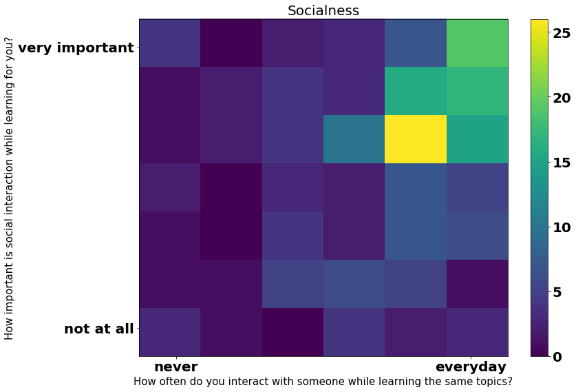

```python
import csv
import matplotlib.pyplot as plt
font = {'family' : 'normal',
        'weight' : 'bold',
        'size'   : 20}
fig_size = plt.rcParams["figure.figsize"]
# Set figure width to 15 and height to 9
fig_size[0] = 12
fig_size[1] = 9
plt.rcParams["figure.figsize"] = fig_size
#print "New size:", fig_size
plt.rc('font', **font)

#primary data array for questionaire
data=[]
#reading in the files
ifile  = open("learn_questions.csv", "r", )
read = csv.reader(ifile)
for row in read :
    data.append(row)

#deleting the top row
del data[0]

#scaling 11 and numeric conversion to make correlation table and heat maps,
#how often do you intearact while learning?
for i in range(len(data)):
    if(data[i][13]=="Everyday"):
        data[i][13]=5
    if(data[i][13]=="Two or three times a week"):
        data[i][13]=4
    if(data[i][13]=="Not at all"):
        data[i][13]=0
    if(data[i][13]=="Two, three times a month"):
        data[i][13]=2
    if(data[i][13]=="Once a few months"):
        data[i][13]=1
    if(data[i][13]=="Once a week"):
        data[i][13]=3

#data printer for checking
# for i in range(len(data)):
#     print data[i][16], data[i][19], data[i][8], data[i][24],data[i][6], data[i][14],


# yes and no's conversion
#scale 16 have you learnt online?
for i in range(len(data)):
    if(data[i][16]=="Yes"):
        data[i][16]=1
    else:
        data[i][16]=0
    #print data[i][16], "data[i][16]"

#scale 19 Have you paid for a course online?
for i in range(len(data)):
    if(data[i][19]=="Yes"):
        data[i][19]=1
    else:
        data[i][19]=0
    #print data[i][19],"data[i][19]"

#scale 8 do you work in a coworking space?
for i in range(len(data)):
    if(data[i][8]=="Yes"):
        data[i][8]=1
    else:
        data[i][8]=0
    #print data[i][8],"data[i][8]"

#scale 24 would you sign up for the learntastic beta?
for i in range(len(data)):
    if(data[i][24]=="Yes"):
        data[i][24]=1
    else:
        data[i][24]=0
    #print data[i][24],"data[i][24]"


#array and plot for 13/14
a13=[]
a14=[]
a16=[]
a19=[]
a8=[]
a24=[]

for i in range(len(data)):
    a13.append(data[i][13])
    a14.append(data[i][14])
    a16.append(data[i][16])
    a19.append(data[i][19])
    a8.append(data[i][8])
    a24.append(data[i][24])


x = np.array(a13).astype(np.float)
y = np.array(a14).astype(np.float)

h1 = plt.hist2d(x, y, bins=(6,7))
plt.xlabel('How often do you interact with someone while learning the same topics?',fontsize=15)
plt.ylabel('How important is social interaction while learning for you?',fontsize=15)
plt.title('Socialness',fontsize=20)
plt.xticks([0.5,4.5],['never','everyday'])
plt.yticks([1.5,6.5],['not at all','very important'])
plt.colorbar(h[3])
plt.show()
```

### Attitudes of all people by occupation towards online learning - Correlation map

```python
block = [[[] for x in range(6)] for x in range(15)]

for i in range(len(data)):
    if(data[i][6]=="Consulting"):
        block[0][0].append(float(data[i][13])* float(data[i][14]))
        block[0][1].append(data[i][16])
        block[0][2].append(data[i][19])
        block[0][3].append(1)
        block[0][4].append(data[i][8])
    if(data[i][6]=="Education"):
        block[1][0].append(float(data[i][13])* float(data[i][14]))
        block[1][1].append(data[i][16])
        block[1][2].append(data[i][19])
        block[1][3].append(1)
        block[1][4].append(data[i][8])
    if(data[i][6]=="Entrepreneurship"):
        block[2][0].append(float(data[i][13])* float(data[i][14]))
        block[2][1].append(data[i][16])
        block[2][2].append(data[i][19])
        block[2][3].append(1)
        block[2][4].append(data[i][8])
    if(data[i][6]=="Management"):
        block[3][0].append(float(data[i][13])* float(data[i][14]))
        block[3][1].append(data[i][16])
        block[3][2].append(data[i][19])
        block[3][3].append(1)
        block[3][4].append(data[i][8])
    if(data[i][6]=="Law"):
        block[4][0].append(float(data[i][13])* float(data[i][14]))
        block[4][1].append(data[i][16])
        block[4][2].append(data[i][19])
        block[4][3].append(1)
        block[4][4].append(data[i][8])
    if(data[i][6]=="Software Development"):
        block[5][0].append(float(data[i][13])* float(data[i][14]))
        block[5][1].append(data[i][16])
        block[5][2].append(data[i][19])
        block[5][3].append(1)
        block[5][4].append(data[i][8])
    if(data[i][6]=="Marketing & PR"):
        block[6][0].append(float(data[i][13])* float(data[i][14]))
        block[6][1].append(data[i][16])
        block[6][2].append(data[i][19])
        block[6][3].append(1)
        block[6][4].append(data[i][8])
    if(data[i][6]=="Design"):
        block[7][0].append(float(data[i][13])* float(data[i][14]))
        block[7][1].append(data[i][16])
        block[7][2].append(data[i][19])
        block[7][3].append(1)
        block[7][4].append(data[i][8])
    if(data[i][6]=="Sales"):
        block[8][0].append(float(data[i][13])* float(data[i][14]))
        block[8][1].append(data[i][16])
        block[8][2].append(data[i][19])
        block[8][3].append(1)
        block[8][4].append(data[i][8])
    if(data[i][6]=="Lifestyle"):
        block[9][0].append(float(data[i][13])* float(data[i][14]))
        block[9][1].append(data[i][16])
        block[9][2].append(data[i][19])
        block[9][3].append(1)
        block[9][4].append(data[i][8])
    if(data[i][6]=="Music"):
        block[10][0].append(float(data[i][13])* float(data[i][14]))
        block[10][1].append(data[i][16])
        block[10][2].append(data[i][19])
        block[10][3].append(1)
        block[10][4].append(data[i][8])
    if(data[i][6]=="Healthcare"):
        block[11][0].append(float(data[i][13])* float(data[i][14]))
        block[11][1].append(data[i][16])
        block[11][2].append(data[i][19])
        block[11][3].append(1)
        block[11][4].append(data[i][8])
    if(data[i][6]=="Finance"):
        block[12][0].append(float(data[i][13])* float(data[i][14]))
        block[12][1].append(data[i][16])
        block[12][2].append(data[i][19])
        block[12][3].append(1)
        block[12][4].append(data[i][8])
    if(data[i][6]!="Finance" and data[i][6]!="Healthcare" and data[i][6]!="Music" and data[i][6]!="Lifestyle" and data[i][6]!="Sales" and data[i][6]!="Design" and data[i][6]!="Marketing & PR" and data[i][6]!="Software Development" and data[i][6]!="Law" and data[i][6]!="Management" and data[i][6]!="Education" and data[i][6]!="Entrepreneurship" and data[i][6]!="Consulting"):
        block[13][0].append(float(data[i][13])* float(data[i][14]))
        block[13][1].append(data[i][16])
        block[13][2].append(data[i][19])
        block[13][3].append(1)
        block[13][4].append(data[i][8])

signi=[]
social=[]
online=[]
pay=[]
cowork=[]
block2 = []

# for value in block:
#     print value

# for i in range(len(block)):
#     for j in [0,1,2,4]:
#         print block[i][j]
#         block2 = np.array(block[i][j]).astype(np.float)
# print block2

for i in range(len(block)):
    for j in [0,1,2,4]:
        block[i][j]=np.average(block[i][j])
    # 7 * 5 is max 35 so normalizing the values
    block[i][0]=block[i][0]/(35)
    # 7 * 7  is max 49 so so normalizing the values
    block[i][3]= float(np.sum(block[i][3]))/48
    signi.append(block[i][3])
    social.append(block[i][0])
    online.append(block[i][1])
    pay.append(block[i][2])
    cowork.append(block[i][4])
```

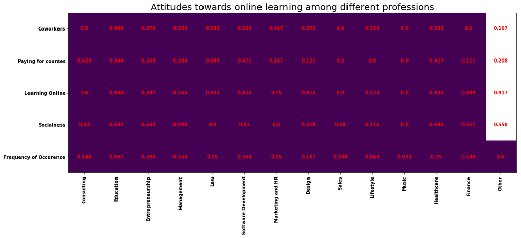

```python
fig = plt.figure(figsize=(60, 55))
ax = fig.add_subplot(131)

xsize = 14
ysize= 5

Z=np.array([signi,social,online,pay,cowork])

im = ax.imshow(Z,origin='lower',extent=[0, xsize, 0, ysize],vmax=abs(Z).max(),vmin=0)

x = np.arange(0,xsize)+0.5
y = np.arange(0,ysize)+0.5

xlabels = ['Consulting','Education','Entrepreneurship','Management','Law','Software Development','Marketing and HR','Design','Sales','Lifestyle','Music','Healthcare','Finance','Other']
ylabels=['Frequency of Occurence','Socialness','Learning Online','Paying for courses','Coworkers' ]
plt.title('Attitudes towards online learning among different professions',fontsize=20)
plt.xticks(x, xlabels,rotation='vertical',fontsize=10)
plt.yticks(y, ylabels,rotation='horizontal',fontsize= 10)

data = np.arange(xsize * ysize).reshape((xsize, ysize))

x_start = 0
x_end = xsize
y_start = 0
y_end = ysize

extent = [x_start, x_end, y_start, y_end]

jump_x = (x_end - x_start) / (2.0 * xsize)
jump_y = (y_end - y_start) / (2.0 * ysize)
x_positions = np.linspace(start=x_start, stop=x_end, num=xsize, endpoint=False)
y_positions = np.linspace(start=y_start, stop=y_end, num=ysize, endpoint=False)

for y_index, y in enumerate(y_positions):
    for x_index, x in enumerate(x_positions):
        label = round(Z[y_index, x_index],3)
        text_x = x + jump_x
        text_y = y + jump_y
        ax.text(text_x, text_y, label, color='red', ha='center', va='center',fontsize=10)
plt.show()
```

### Education, Developers and Enterprenuers were the most frequently occuring personas in the data set.